# avance3

Abraham Nieto 51556

11 de diciembre de 2018

```r
library(tidyverse)
library(readr)
library(stringr)
library(lubridate)
```

```r
library(ggplot2)
library(Amelia)
#-Working directory-
wdir<-"/home/abraham/FE2018/proyfin/"
setwd(wdir)
```

```r
frax<-read.csv("d4a_fraud_data.csv",header = TRUE)
frax<-frax%>%select(gender,state,cardholder,balance,numTrans,numIntlTrans,creditLine,fraudRisk)
head(frax)
```

```
##   gender state cardholder balance numTrans numIntlTrans creditLine
## 1      1    35          1    3000        4           14          2
## 2      2     2          1       0        9            0         18
## 3      2     2          1       0       27            9         16
## 4      1    15          1       0       12            0          5
## 5      1    46          1       0       11           16          7
## 6      2    44          2    5546       21            0         13
##   fraudRisk
## 1         0
## 2         0
## 3         0
## 4         0
## 5         0
## 6         0
```

De acuerdo con los comentarios del profesor vamos a a segmentar la variable balance y encontramos los siguiente:

```r
x <- frax$balance  # some data
quintiles <- quantile(x, probs=seq(0.2, 1, by = 0.2))
new<-cut(x, quintiles, ordered = TRUE,label=1:4)#quantile(x,quintiles)
new[is.na(new)] <- 1
frax$balance_q<-new
```

```r
library(dplyr)
frax%>%group_by(balance_q)%>%summarise(ctes=n(),tasa_f=round(mean(fraudRisk)*100,2),total_f=sum(fraudRisk))%>%
  mutate(proporcion_f=round(total_f/sum(total_f)*100,2),proporcion_ctes=round(ctes/sum(ctes)*100,2))
```

```
## # A tibble: 4 x 6
##   balance_q  ctes tasa_f total_f proporcion_f proporcion_ctes
##       <ord> <int>  <dbl>   <int>        <dbl>           <dbl>
## 1         1 40000   1.05     419         6.92           40.00
## 2         2 20002   1.65     330         5.45           20.00
## 3         3 21519   4.01     862        14.23           21.52
## 4         4 18479  24.07    4447        73.41           18.48
```

Después de segmentar la variable balance por cuartiles podemos observar con la ayuda de la tabla anterior que el 73% del fraude se concentra en el segmento 4 que contiene tan solo el 18% de los clientes, recordar que el segmento 4 son aquellos clientes con un balance mayor a los 7 mil dólares, también es importante notar que la tasa de fraude en este segmento es de más del 24% lo que nos indica que es 4 veces mayor a la densidad original que es del 6%.

Ahora si revisamos la variable creditLine o tipo de línea de crédito encontramos los siguiente

```r
x <- frax$creditLine  # some data
quintiles2 <- quantile(x, probs=seq(0, 1, by = 0.25))
new2<-cut(x, quintiles2, ordered = TRUE,label=1:4)#quantile(x,quintiles)
new2[is.na(new2)] <- 1
frax$credl_q<-new2
```

```r
frax%>%group_by(credl_q)%>%summarise(ctes=n(),tasa_f=round(mean(fraudRisk)*100,2),total_f=sum(fraudRisk))%>%
  mutate(proporcion_f=round(total_f/sum(total_f)*100,2),proporcion_ctes=round(ctes/sum(ctes)*100,2))
```

```
## # A tibble: 4 x 6
##   credl_q  ctes tasa_f total_f proporcion_f proporcion_ctes
##     <ord> <int>  <dbl>   <int>        <dbl>           <dbl>
## 1       1 36092   0.82     296         4.89           36.09
## 2       2 17670   2.05     363         5.99           17.67
## 3       3 23296   4.76    1110        18.32           23.30
## 4       4 22942  18.69    4289        70.80           22.94
```

Haciendo 4 segmentos en los tipos de líneas de créditos podemos observar que el segemento 4 que se refiere del tipo 11 en adelante contiene el 70% de los clientes fraudulentos y representa casi el 23% de los clientes totales, además la tasa de fraude en este segmento es del 18.7% lo cual es más de 3 veces mayor que la densidad original de de 6% entonces es 3 veces más probable que haya clientes o casos de fraude en este segmento, por otro lado dentro de la segementación de esta varible el segmento 3 que representa los tipos entre 6 y 11 tiene una tasa de fraude de 4.76% la cual es menor que la densidad original al iguial que los segmentos 1 y 2 con tasas de fraude de .82% y 2.05% respectivamente.

Ahora dado que nuestro objetivo es construir un modelo de propensión de fraude hace todo el sentido mezclar los segmentos de ambas variables de tal forma que para tener mayor asertividad en la propensión hagamos 1 modelo para cada segmento utilizando el resto de las variables como explicativas.

Cruzando los distintos segmentos tenemos los siguientes resultados:

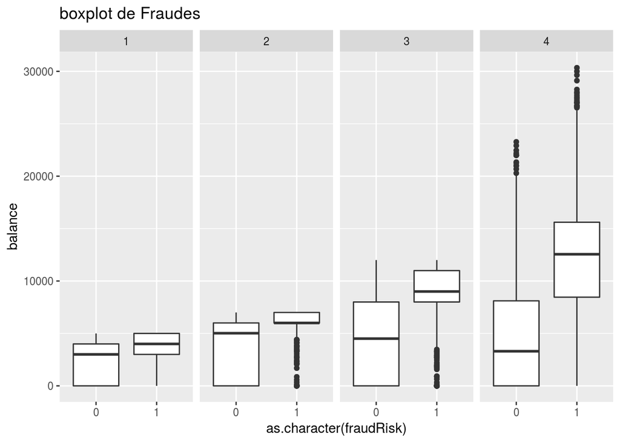

```r
ggplot(frax, aes(x=as.character(fraudRisk), y=balance)) +
  geom_boxplot() + facet_grid(~credl_q)+
  scale_fill_manual(values=c("darkcyan", "magenta")) +
  ggtitle("boxplot de Fraudes")
```

Si observamos los diagramas de caja y brazos de los 4 segmentos de los tipos de lineas de créditto a través de su balance o saldo vemos que para el segmento 4 la diferencia entre las distribuciones de balance de los casos de fraude y no fraude se diferencian de forma muy clara, lo cual hace pensar que en este segmento sería más sencillo encontrar un modelo que discrimine a los cientes más propensos a ser casos de fraude, en los primeros 2 segemetos pudiera ser más complejo dado que las cajas se traslapan.

## Segmentos

Análizando los segmentos mezclados de las variables balance y creditLine encontramos que…

```r
seg<-frax%>%group_by(balance_q,credl_q)%>%summarise(ctes=n(),tasa_f=round(mean(fraudRisk)*100,2),
                                               total_f=sum(fraudRisk))
seg%>%mutate(proporcion_f=round(total_f/6058*100,2),
proporcion_ctes=round(ctes/100000*100,2))%>%arrange(desc(proporcion_f))
```

```
## # A tibble: 14 x 7
## # Groups:   balance_q [4]
##    balance_q credl_q  ctes tasa_f total_f proporcion_f proporcion_ctes
##        <ord>   <ord> <int>  <dbl>   <int>        <dbl>           <dbl>
##  1         4       4  9136  38.43    3511        57.96            9.14
##  2         4       3  9343  10.02     936        15.45            9.34
##  3         3       4  2916  11.21     327         5.40            2.92
##  4         3       2  9520   3.37     321         5.30            9.52
##  5         1       4  9075   3.28     298         4.92            9.07
##  6         2       4  1815   8.43     153         2.53            1.82
##  7         2       1 15034   0.89     134         2.21           15.03
##  8         3       1  6184   1.86     115         1.90            6.18
##  9         3       3  2899   3.41      99         1.63            2.90
## 10         1       3  9255   0.55      51         0.84            9.25
## 11         1       1 14874   0.32      47         0.78           14.87
## 12         2       3  1799   1.33      24         0.40            1.80
## 13         1       2  6796   0.34      23         0.38            6.80
## 14         2       2  1354   1.40      19         0.31            1.35
```

El segmento (4,4) (balance,creditLine) contiene el 58% de los casos de fraude mientras que su densidad de fraude es de 38.43%, este segemento es donde de manera más sencilla se pueden encontrar los casos fruadulentos, luego los segmentos (4,3) y (3,4) representan casi el 21% del total de los casos de fraude con una tasa de casos de fraude de más del 10% es decir con estos 3 segmentos se cubre casi el 79% de los casos fraudulentos, lo que estamos haciendo con estos cruces de segmentos es crear categorías de mayor a menor “facilidad” para detectar los casos, entonces la idea es que los modelos que construyamos encuentren probabilidades más asertivas en estos 2 segementos y obviamente mucho menores en el resto de ellos. En términos de negocio queremos encontrar 3 tipos de segmentos, digamos alto, medio y bajo donde podamos saber que la probabilidad de encontrar casosde fraude va de mayor a menor, de tal forma que podamos atacar este problema de detección en cada uno de ellos.

Por tanto, se definen los siguientes segmentos: Alto= {segmento (4,4)} Medio={segmento (4,3), segmento (3,4)} Bajo={todos los segmentos}-{Alto,Medio}

```r
frax$Segmento<-ifelse(frax$balance_q==4 & frax$credl_q==4,"Alto",
                      ifelse(as.numeric(frax$balance_q)*as.numeric(frax$credl_q)==12,"Medio","Bajo"))
```

```r
frax%>%group_by(Segmento)%>%summarise(ctes=n(),tasa_f=round(mean(fraudRisk)*100,2),total_f=sum(fraudRisk))%>%
  mutate(proporcion_f=round(total_f/sum(total_f)*100,2),proporcion_ctes=round(ctes/sum(ctes)*100,2))
```

```
## # A tibble: 3 x 6
##   Segmento  ctes tasa_f total_f proporcion_f proporcion_ctes
##      <chr> <int>  <dbl>   <int>        <dbl>           <dbl>
## 1     Alto  9136  38.43    3511        57.96            9.14
## 2     Bajo 78605   1.63    1284        21.20           78.61
## 3    Medio 12259  10.30    1263        20.85           12.26
```

Finalmente con estos 3 segmentos podemos observar que para el segmento Alto e detecta el 58% delos casos de fraude analizando sólo el 9% de los clientes, para el Medio se detecta el 21% de los fraudes con el 12.2% de los clientes ambos con densidades o tasas de fraude mayores a la original, para el segmento más bajo tiene una densidad del 1.6%.

## Data Partition

Vamos a Partir a los datos 70% entrenamiento y 30% test.

```r
library(caret)
set.seed(3456)
trainIndex <- createDataPartition(frax$fraudRisk, p = .7,
                                  list = FALSE,
                                  times = 1)
fraxTrain <- frax[ trainIndex,]
fraxTest  <- frax[-trainIndex,]
```

```r
library("LearnBayes")
fraxTrain_1<-fraxTrain%>%filter(Segmento=="Alto")
fraxTest_1<-fraxTest%>%filter(Segmento=="Alto")
nrow(fraxTrain_1)
```

```
## [1] 6363
```

```r
range01 <- function(x){(x-min(x))/(max(x)-min(x))}
fit <- lm(fraudRisk~range01(gender)+range01(state)+range01(numTrans)+range01(numIntlTrans),data=fraxTrain_1,family = binomial(link="logit"),x=TRUE,y=TRUE)
summary(fit)
```

```
##
## Call:
## lm(formula = fraudRisk ~ range01(gender) + range01(state) + range01(numTrans) +
##     range01(numIntlTrans), data = fraxTrain_1, x = TRUE, y = TRUE,
##     family = binomial(link = "logit"))
##
## Residuals:
##     Min      1Q  Median      3Q     Max
## -1.0116 -0.3254 -0.2117  0.4694  0.8931
##
## Coefficients:
##                       Estimate Std. Error t value Pr(>|t|)
## (Intercept)            0.18135    0.01329  13.641  < 2e-16 ***
## range01(gender)        0.08897    0.01158   7.679 1.84e-14 ***
## range01(state)        -0.09410    0.01886  -4.988 6.25e-07 ***
## range01(numTrans)      0.64517    0.02092  30.845  < 2e-16 ***
## range01(numIntlTrans)  0.28258    0.03695   7.648 2.35e-14 ***
## ---
## Signif. codes:  0 '***' 0.001 '**' 0.01 '*' 0.05 '.' 0.1 ' ' 1
##
## Residual standard error: 0.4495 on 6358 degrees of freedom
## Multiple R-squared:  0.1444, Adjusted R-squared:  0.1439
## F-statistic: 268.3 on 4 and 6358 DF,  p-value: < 2.2e-16
```

```r
## CIs using profiled log-likelihood
confint(fit)
```

```
##                             2.5 %      97.5 %
## (Intercept)            0.15528875  0.20741248
## range01(gender)        0.06625484  0.11167551
## range01(state)        -0.13108506 -0.05712246
## range01(numTrans)      0.60416995  0.68617646
## range01(numIntlTrans)  0.21015009  0.35501839
```

```r
## odds ratios only
exp(coef(fit))
```

```
##           (Intercept)       range01(gender)        range01(state)
##             1.1988354             1.0930426             0.9101883
##     range01(numTrans) range01(numIntlTrans)
##             1.9063172             1.3265535
```

```r
## odds ratios and 95% CI
exp(cbind(OR = coef(fit), confint(fit)))
```

```
##                              OR     2.5 %    97.5 %
## (Intercept)           1.1988354 1.1679952 1.2304900
## range01(gender)       1.0930426 1.0684990 1.1181500
## range01(state)        0.9101883 0.8771432 0.9444784
## range01(numTrans)     1.9063172 1.8297328 1.9861070
## range01(numIntlTrans) 1.3265535 1.2338632 1.4262069
```

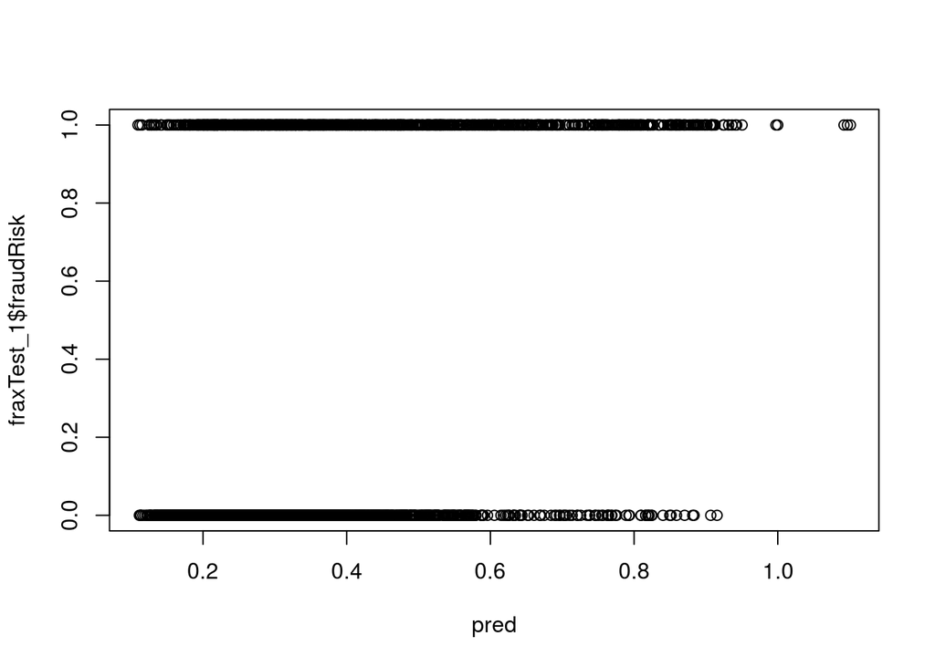

```r
pred<-predict(fit, newdata = fraxTest_1,type = "response")
plot(pred,fraxTest_1$fraudRisk)
```

```r
#plot(fraxTest_1$fraudRisk,exp(pred))
#p_class <- factor(fraxTest_1$fraudRisk)
p_pred<-ifelse(pred>=.5,1,0)
confusionMatrix(p_pred,fraxTest_1$fraudRisk,positive='1')
```

```
## Confusion Matrix and Statistics
##
##           Reference
## Prediction    0    1
##          0 1521  676
##          1  169  407
##
##                Accuracy : 0.6953
##                  95% CI : (0.6778, 0.7124)
##     No Information Rate : 0.6094
##     P-Value [Acc > NIR] : < 2.2e-16
##
##                   Kappa : 0.3011
##  Mcnemar's Test P-Value : < 2.2e-16
##
##             Sensitivity : 0.3758
##             Specificity : 0.9000
##          Pos Pred Value : 0.7066
##          Neg Pred Value : 0.6923
##              Prevalence : 0.3906
##          Detection Rate : 0.1468
##    Detection Prevalence : 0.2077
##       Balanced Accuracy : 0.6379
##
##        'Positive' Class : 1
##
```

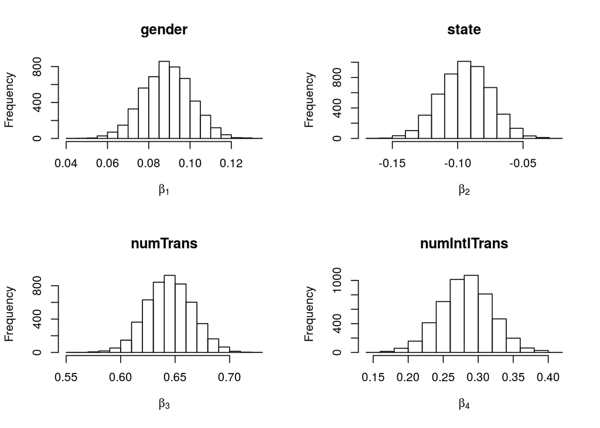

```r
beta.sample <- blinreg(fit$y,fit$x,5000)
par(mfrow=c(2,2))
hist(beta.sample$beta[,2],main="gender",
 xlab=expression(beta[1]))
hist(beta.sample$beta[,3],main="state",
 xlab=expression(beta[2]))
hist(beta.sample$beta[,4],main="numTrans",
 xlab=expression(beta[3]))
hist(beta.sample$beta[,5],main="numIntlTrans",
 xlab=expression(beta[4]))
```

```r
#library(lme4)
#fit <- glmer(fraudRisk ~ (1 | Segmento)+range01(gender)+range01(state)+range01(numTrans)+range01(numIntlTrans), family = binomial("logit"), data = fraxTrain_1)
#summary(fit)
```

```r
#exp(-2.2512 )
```